# Part 2 Random Forest

Harrison Cradduck, Nick Berry

2025-11-07

# 1 Introduction

**Using the methods we discussed in class, develop the best Random Forest tree that you can. Tune hyperparameters to improve model performance.**

# 2 Data Loading

Loading in the training and holdout files, both our origiinal versions and our improved versions.

```r
# read in .csv training data file
data_train <- readRDS("../data/final_cleaned_train_part2.rds")
```

```r
# read in .csv holdout data file
data_holdout <- readRDS("../data/final_cleaned_holdout_part2.rds")
```

```r
# read in .csv training data file
data_train_better <- readRDS("../data/final_cleaned_train_part2_better.rds")
```

```r
# read in .csv holdout data file
data_holdout_better <- readRDS("../data/final_cleaned_holdout_part2_better.rds")
```

## 2.1 Dummy-coding

Dummy-coded the factors in the improved training and holdout sets.

```r
# set response variable
response <- "loan_default"

# set predictor variables
predictor_cols <- setdiff(names(data_train_better), response)

# create dummy variables for all factor columns in data_train
data_train_dummy <- fastDummies::dummy_cols(
  data_train_better[, predictor_cols],
  remove_first_dummy = FALSE,
  remove_selected_columns = TRUE
)
data_train_dummy[[response]] <- data_train_better[[response]]

colnames(data_train_dummy) <- make.names(colnames(data_train_dummy))

# create dummy variables for all factor columns in data_holdout
data_holdout_dummy <- fastDummies::dummy_cols(
  data_holdout_better[, predictor_cols],
  remove_first_dummy = FALSE,
  remove_selected_columns = TRUE
)
data_holdout_dummy[[response]] <- data_holdout_better[[response]]

colnames(data_holdout_dummy) <- make.names(colnames(data_train_dummy))
```

## 2.2 Downsampling

Downsampled the original, improved, and dummy-coded training data sets.

```r
# down-sample the training data
data_train_ds <- ovun.sample(loan_default ~ ., data = data_train, method = "under")$data
```

```r
# down-sample the training data
data_train_ds_better <- ovun.sample(loan_default ~ ., data = data_train_better, method = "under")$data
```

```r
# down-sample the dummy training data
data_train_dummy_ds <- ovun.sample(loan_default ~ ., data = data_train_dummy, method = "under")$data
```

# 3 Modeling

Set seed for reproducibility, create cluster for parallel processing, and set up cross-validation and mtry sequence.

```r
# set seed for reproducibility
set.seed(123)
```

```r
# detect available cores
n_cores <- parallel::detectCores() - 1

# create and register cluster
cl <- makeCluster(n_cores)
registerDoParallel(cl)
```

```r
# set up cross-validation
ctrl <- trainControl(
  method = "cv",
  number = 5,
  classProbs = TRUE,
  summaryFunction = twoClassSummary,
  savePredictions = "final",
  allowParallel = TRUE
)

# iterate through values of mtry
rf_grid <- expand.grid(mtry = seq(15, ncol(data_train) - 1, 2))
```

**We tried sequencing mtry from 1 to 10 and 10 was chosen. We tried sequencing mtry from 10 to 20 and 20 was chosen. We settled on sequencing mtry from 15 to number of columns - 1.**

## 3.1 Downsampled Random Forest

```r
# fit a single random forest using caret
# rf_tree1 <- train(
#   loan_default ~ .,
#   data = data_train_ds,
#   method = "rf",
#   metric = "ROC",
#   trControl = ctrl,
#   tuneGrid = rf_grid,
#   ntree = 100,
#   nodesize = 100,
#   importance = TRUE
# )

rf_tree1 <- read_rds("rf_tree1.rds")

# predict probabilities on holdout
rf_tree1_pred_prob <- predict(rf_tree1, data_holdout, type = "prob")[, "Yes"]

# create true labels (1 = Yes, 0 = No)
true_labels <- ifelse(data_holdout$loan_default == "Yes", 1, 0)

# use ROCR to evaluate across thresholds
pred <- ROCR::prediction(rf_tree1_pred_prob, true_labels)

# get precision-recall performance
perf <- ROCR::performance(pred, measure = "prec", x.measure = "rec")

# compute AUC
perf_auc <- ROCR::performance(pred, measure = "auc")
auc_ds <- perf_auc@y.values[[1]]
print(auc_ds)
```

```
## [1] 0.8480926
```

```r
# get mtry
rf_tree1$bestTune$mtry
```

```
## [1] 27
```

```r
# extract values
precision <- perf@y.values[[1]]
recall <- perf@x.values[[1]]
thresholds <- perf@alpha.values[[1]]

# compute F1
f1 <- 2 * (precision * recall) / (precision + recall)
f1[is.nan(f1)] <- 0

# find best threshold and F1
best_index_ds <- which.max(f1)
best_thresh_ds <- thresholds[best_index_ds]
best_f1_ds <- f1[best_index_ds]

# print results
cat("Best threshold:", best_thresh_ds, "\n")
```

```
## Best threshold: 0.73
```

```r
cat("Best F1 score:", best_f1_ds, "\n")
```

```
## Best F1 score: 0.5911152
```

```r
# create final class predictions using best threshold
rf_tree1_pred_class <- factor(
  ifelse(rf_tree1_pred_prob >= best_thresh_ds, "Yes", "No"),
  levels = c("No", "Yes")
)

# confusion matrix with optimal threshold
cm <- caret::confusionMatrix(rf_tree1_pred_class, data_holdout$loan_default, positive = "Yes")
print(cm)
```

```
## Confusion Matrix and Statistics
##
##           Reference
## Prediction    No   Yes
##        No  54652  5237
##        Yes  9011 10299
##
##                Accuracy : 0.8201
##                  95% CI : (0.8174, 0.8228)
##     No Information Rate : 0.8038
##     P-Value [Acc > NIR] : < 2.2e-16
##
##                   Kappa : 0.4775
##
##  Mcnemar's Test P-Value : < 2.2e-16
##
##             Sensitivity : 0.6629
##             Specificity : 0.8585
##          Pos Pred Value : 0.5334
##          Neg Pred Value : 0.9126
##              Prevalence : 0.1962
##          Detection Rate : 0.1300
##    Detection Prevalence : 0.2438
##       Balanced Accuracy : 0.7607
##
##        'Positive' Class : Yes
##
```

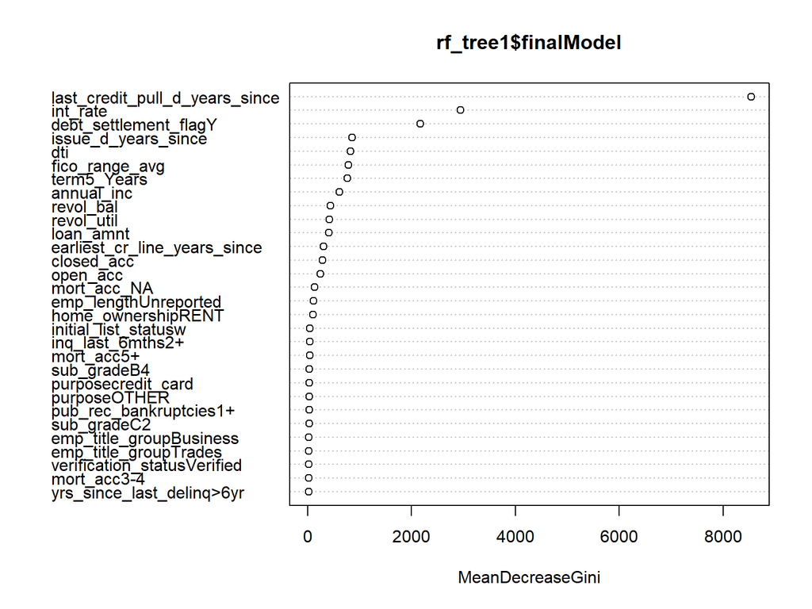

```r
# variable importance plot
randomForest::varImpPlot(rf_tree1$finalModel, type = 2)
```

**We fit a 5-fold cross-validated random forest model on the original training data with 100 trees, a minimum nodesize of 100, and optimized using ROC over the default accuracy. The model metrics are as follows: AUC = 0.848, mtry = 27, accuracy = 0.820, sensitivity = 0.663, and specificity = 0.859. The best threshold optimized by F1 score is 0.73 with an F1 score of 0.591.**

```r
# save as .rds file to avoid refitting
# write_rds(rf_tree1, "rf_tree1.rds")
```

**We saved the tree as a .rds file to avoid refitting and allow us to read the .rds file above.**

```r
# extract variable importance
var_imp_rf_tree1 <- varImp(rf_tree1)$importance

# collapse Yes/No into one overall measure
var_imp_rf_tree1_df <- var_imp_rf_tree1 %>%
  tibble::rownames_to_column("Variable") %>%
  mutate(Overall = rowMeans(across(where(is.numeric)), na.rm = TRUE)) %>%
  select(Variable, Overall) %>%
  arrange(desc(Overall))
```

**We created a dataframe with the variable importance for the random forest model.**

## 3.2 Improved Downsampled Random Forest

```r
# fit a single random forest using caret
# rf_tree1_better <- train(
#   loan_default ~ .,
#   data = data_train_ds_better,
#   method = "rf",
#   metric = "ROC",
#   trControl = ctrl,
#   tuneGrid = rf_grid,
#   ntree = 100,
#   nodesize = 100,
#   importance = TRUE
# )

rf_tree1_better <- read_rds("rf_tree1_better.rds")

# predict probabilities on holdout
rf_tree1_better_pred_prob <- predict(rf_tree1_better, data_holdout_better, type = "prob")[, "Yes"]

# create true labels (1 = Yes, 0 = No)
true_labels <- ifelse(data_holdout_better$loan_default == "Yes", 1, 0)

# use ROCR to evaluate across thresholds
pred <- ROCR::prediction(rf_tree1_better_pred_prob, true_labels)

# get precision-recall performance
perf <- ROCR::performance(pred, measure = "prec", x.measure = "rec")

# compute AUC
perf_auc <- ROCR::performance(pred, measure = "auc")
auc_ds_imp <- perf_auc@y.values[[1]]
print(auc_ds_imp)
```

```
## [1] 0.8469346
```

```r
# get mtry
rf_tree1_better$bestTune$mtry
```

```
## [1] 27
```

```r
# extract values
precision <- perf@y.values[[1]]
recall <- perf@x.values[[1]]
thresholds <- perf@alpha.values[[1]]

# compute F1
f1 <- 2 * (precision * recall) / (precision + recall)
f1[is.nan(f1)] <- 0

# find best threshold and F1
best_index_ds_imp <- which.max(f1)
best_thresh_ds_imp <- thresholds[best_index_ds_imp]
best_f1_ds_imp <- f1[best_index_ds_imp]

# print results
cat("Best threshold:", best_thresh_ds_imp, "\n")
```

```
## Best threshold: 0.72
```

```r
cat("Best F1 score:", best_f1_ds_imp, "\n")
```

```
## Best F1 score: 0.5933074
```

```r
# create final class predictions using best threshold
rf_tree1_better_pred_class <- factor(
  ifelse(rf_tree1_better_pred_prob >= best_thresh_ds_imp, "Yes", "No"),
  levels = c("No", "Yes")
)

# confusion matrix with optimal threshold
cm <- caret::confusionMatrix(rf_tree1_better_pred_class, data_holdout_better$loan_default, positive = "Yes")
print(cm)
```

```
## Confusion Matrix and Statistics
##
##           Reference
## Prediction    No   Yes
##        No  54271  5022
##        Yes  9392 10514
##
##                Accuracy : 0.818
##                  95% CI : (0.8153, 0.8207)
##     No Information Rate : 0.8038
##     P-Value [Acc > NIR] : < 2.2e-16
##
##                   Kappa : 0.4784
##
##  Mcnemar's Test P-Value : < 2.2e-16
##
##             Sensitivity : 0.6768
##             Specificity : 0.8525
##          Pos Pred Value : 0.5282
##          Neg Pred Value : 0.9153
##              Prevalence : 0.1962
##          Detection Rate : 0.1328
##    Detection Prevalence : 0.2513
##       Balanced Accuracy : 0.7646
##
##        'Positive' Class : Yes
##
```

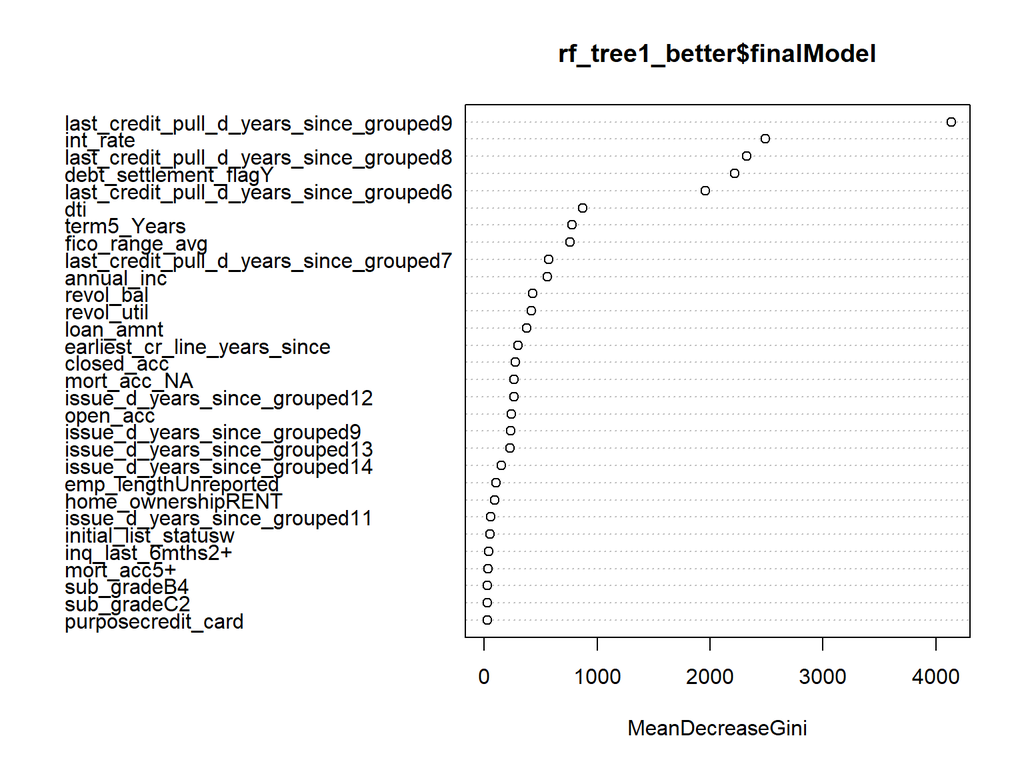

```r
# variable importance plot
randomForest::varImpPlot(rf_tree1_better$finalModel, type = 2)
```

```r
# save as .rds file to avoid refitting
# write_rds(rf_tree1_better, "rf_tree1_better.rds")
```

**We saved the tree as a .rds file to avoid refitting and allow us to read the .rds file above.**

```r
# extract variable importance
var_imp_rf_tree1_better <- varImp(rf_tree1_better)$importance

# collapse Yes/No into one overall measure
var_imp_rf_tree1_better_df <- var_imp_rf_tree1_better %>%
  tibble::rownames_to_column("Variable") %>%
  mutate(Overall = rowMeans(across(where(is.numeric)), na.rm = TRUE)) %>%
  select(Variable, Overall) %>%
  arrange(desc(Overall))
```

**We created a dataframe with the variable importance for the random forest model.**

## 3.3 Dummy-coded Random Forest

```r
# # fit a single random forest using caret
# # rf_tree2 <- train(
# #   loan_default ~ .,
# #   data = data_train_dummy,
# #   method = "rf",
# #   metric = "ROC",
# #   trControl = ctrl,
# #   tuneGrid = rf_grid,
# #   ntree = 100,
# #   nodesize = 100,
# #   importance = TRUE
# # )
#
# # read in .rds file
# rf_tree2 <- read_rds("rf_tree2.rds")
#
# # predict probabilities on holdout
# rf_tree32pred_prob <- predict(rf_tree2, data_holdout_dummy, type = "prob")[, "Yes"]
#
# # create true labels (1 = Yes, 0 = No)
# true_labels <- ifelse(data_holdout_dummy$loan_default == "Yes", 1, 0)
#
# # use ROCR to evaluate across thresholds
# pred <- ROCR::prediction(rf_tree1_pred_prob, true_labels)
#
# # get precision-recall performance
# perf <- ROCR::performance(pred, measure = "prec", x.measure = "rec")
#
# # compute AUC
# perf_auc <- ROCR::performance(pred, measure = "auc")
# auc <- perf_auc@y.values[[1]]
# print(auc)
#
# # get mtry
# rf_tree2$bestTune$mtry
#
# # extract values
# precision <- perf@y.values[[1]]
# recall <- perf@x.values[[1]]
# thresholds <- perf@alpha.values[[1]]
#
# # compute F1
# f1 <- 2 * (precision * recall) / (precision + recall)
# f1[is.nan(f1)] <- 0
#
# # find best threshold and F1
# best_index <- which.max(f1)
# best_thresh <- thresholds[best_index]
# best_f1 <- f1[best_index]
#
# # print results
# cat("Best threshold:", best_thresh, "\n")
# cat("Best F1 score:", best_f1, "\n")
#
# # create final class predictions using best threshold
# rf_tree2_pred_class <- factor(
#   ifelse(rf_tree2_pred_prob >= best_thresh, "Yes", "No"),
#   levels = c("No", "Yes")
# )
#
# # confusion matrix with optimal threshold
# cm <- caret::confusionMatrix(rf_tree2_pred_class, data_holdout_dummy$loan_default, positive = "Yes")
# print(cm)
#
# # variable importance plot
# randomForest::varImpPlot(rf_tree3$finalModel, type = 2)
```

```r
# save as .rds file to avoid refitting
# write_rds(rf_tree2, "rf_tree2.rds")
```

**We saved the tree as a .rds file to avoid refitting and allow us to read the .rds file above.**

```r
# # extract variable importance
# var_imp_rf_tree2 <- varImp(rf_tree2)$importance
#
# # collapse Yes/No into one overall measure
# var_imp_rf_tree2_df <- var_imp_rf_tree2 %>%
#   tibble::rownames_to_column("Variable") %>%
#   mutate(Overall = rowMeans(across(where(is.numeric)), na.rm = TRUE)) %>%
#   select(Variable, Overall) %>%
#   arrange(desc(Overall))
```

```r
stopCluster(cl)
registerDoSEQ()
```

# 4 Model Comparison

```r
# compare models
comparison <- data.frame(
  Model = c("Downsampled", "Improved Downsampled"),
  AUC = c(auc_ds, auc_ds_imp),
  Best_Threshold = c(best_thresh_ds, best_thresh_ds_imp),
  Best_F1 = c(best_f1_ds, best_f1_ds_imp)
)
comparison <- comparison[order(-comparison$Best_F1), ]
print(comparison)
```

```
##                  Model       AUC Best_Threshold   Best_F1
## 2 Improved Downsampled 0.8469346           0.72 0.5933074
## 1          Downsampled 0.8480926           0.73 0.5911152
```

**The model comparison above shows that the model fit using the improved downsampled training data set results in the highest F1 score. Both models result in very similar F1 scores and thresholds.**

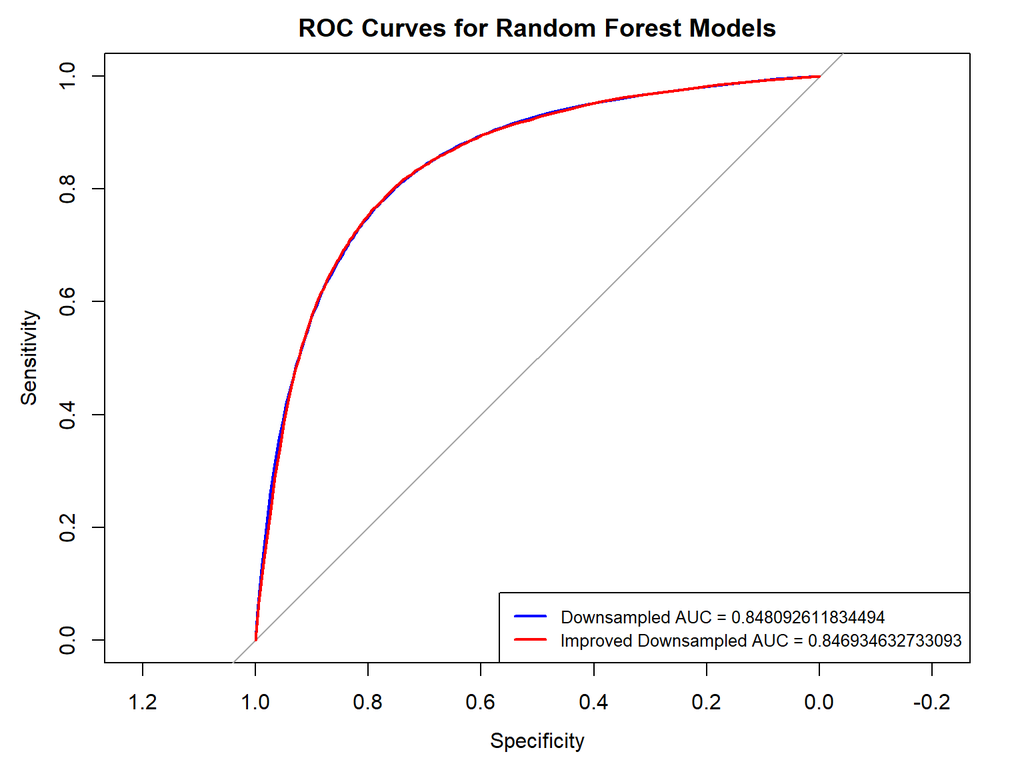

```r
# compare models by plotting ROC curves
roc_ds <- pROC::roc(data_holdout$loan_default, predict(rf_tree1, data_holdout, type = "prob")[, "Yes"])
roc_ds_imp <- pROC::roc(data_holdout_better$loan_default, predict(rf_tree1_better, data_holdout_better, type = "prob")[, "Yes"])

plot(roc_ds, col = "blue", lwd = 2, main = "ROC Curves for Random Forest Models")
plot(roc_ds_imp, add = TRUE, col = "red", lwd = 2)

legend("bottomright",
       legend = c(
         paste0("Downsampled AUC = ", auc_ds),
         paste0("Improved Downsampled AUC = ", auc_ds_imp)
       ),
       col = c("blue", "red", "darkgreen"),
       lwd = 2,
       cex = 0.8)
```

**The ROC curve comparison above shows almost the exact same curve for both models. In terms of AUC, the model fit using the downsampled training data set has the highest value at 0.8481, and the model fit using the improved downsampled training data set has the second highest value at 0.8469.**

# 5 Final Model

**The final Random Forest model chosen is the model trained on the improved downsampled training data set built using 5-fold cross validation, a minimum nodesize of 100, an optimal mtry of 27, and fitting 100 trees. The model was evaluated on the improved downsampled holdout data set, and an optimal probability threshold of 0.72 was selected to maximize the F1 score at 0.5933074. This threshold-adjusted tree represents our final classification rule, optimized for F1 balance between precision and recall.**